# AIML_ML_Project_full_code_notebook-Sunil

### Model Building

```python
# Define a function to compute different metrics for evaluating the performance of a classification model built using sklearn
def model_performance_classification_sklearn(model, predictors, target):
    """
    Compute various metrics to evaluate classification model performance.
    Parameters:
    model (sklearn classifier): The trained classification model
    predictors (array-like): Independent variables used for prediction
    target (array-like): True labels for the target variable
    Returns:
    pandas.DataFrame: A single-row dataframe containing Accuracy, Recall, Precision, and F1 score
    """
    # Make predictions using the independent variables
    pred = model.predict(predictors)
    # Compute Accuracy: the proportion of correct predictions (both true positives and true negatives) among the total number
    acc = accuracy_score(target, pred)
    # Compute Recall: the proportion of actual positive cases that were correctly identified
    recall = recall_score(target, pred)
    # Compute Precision: the proportion of predicted positive cases that are actually positive
    precision = precision_score(target, pred)
    # Compute F1-score: the harmonic mean of precision and recall, providing a single score that balances both metrics
    f1 = f1_score(target, pred)
    # Create a dataframe to store and return all computed metrics
    df_perf = pd.DataFrame(
        {"Accuracy": acc, "Recall": recall, "Precision": precision, "F1": f1,},
        index=[0],
    )
    # Return the  dataframe of performance metrics
    return df_perf
```

```python
# Define a function to create and display a confusion matrix
def confusion_matrix_sklearn(model, predictors, target):
    """
    Plot the confusion matrix with percentages for a classification model.
    Parameters:
    model: classifier object
    predictors: independent variables (features)
    target: dependent variable (true labels)
    """
    # Generate predictions using the model
    y_pred = model.predict(predictors)
    # Compute the confusion matrix
    cm = confusion_matrix(target, y_pred)
    # Create labels for the confusion matrix
    # Each cell will display count and percentage
    labels = np.asarray(
        [
            ["{0:0.0f}".format(item) + "\n{0:.2%}".format(item / cm.flatten().sum())]
            for item in cm.flatten()
        ]
         ).reshape(2, 2)
    # Set up the matplotlib figure
    plt.figure(figsize=(6, 4))
    # Create a heatmap of the confusion matrix
    # annot=labels adds the custom labels to each cell
    sns.heatmap(cm, annot=labels, fmt="") # cm is now defined within the function's scope
    # Set labels for the axes
    plt.ylabel("True label")
    plt.xlabel("Predicted label")
    # Return the confusion matrix for potential later use if needed
    return cm # Returning cm to make it accessible outside the function if needed
```

**Build Decision Tree Model**

```python
# Building a decision tree model
model = DecisionTreeClassifier(criterion="gini", random_state=1)
model.fit(X_train, y_train)
```

```
DecisionTreeClassifier(random_state=1)
```

**Checking model performance on training data**

```
array([[3169,    0],
       [   0,  331]])
```

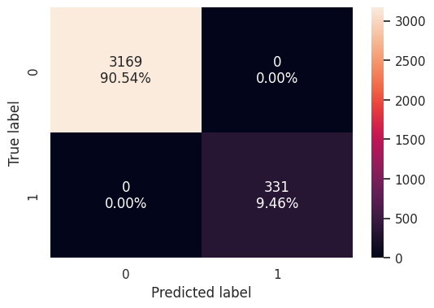

```python
confusion_matrix_sklearn(model, X_train, y_train)
```

```python
# Compute and display the performance metrics for the training set
decision_tree_perf_train = model_performance_classification_sklearn(
 model, X_train, y_train
 )
decision_tree_perf_train
```

|  | Accuracy | Recall | Precision | F1 |
| --- | --- | --- | --- | --- |
| 0 | 1.0 | 1.0 | 1.0 | 1.0 |

- The classification model has achieved perfect performance metrics across the board, with an Accuracy, Recall, Precision, and F1-score all equal to 1.0. This indicates that the model correctly classified all instances, with no false positives or false negatives.
- While this is an ideal result, it is important to consider whether this performance is realistic or if it might indicate overfitting, especially if the model was evaluated on the training data or a non-representative test set

**Visualizing the Decision Tree for the training data**

```python
# Extract and print feature names from the training dataset
feature_names = list(X_train.columns)
print(feature_names)
```

```
['ID', 'Age', 'Income', 'Family', 'CCAvg', 'Mortgage', 'Securities_Account', 'CD_Account', 'Online', 'CreditCard', 'ZIPCode_90007', 'ZIPCode_90009', 'ZIPCode_90011', 'ZIPCode_90016', 'ZIPCode_90018', 'ZIPCode_90019', 'ZIPCode_90024', 'ZIPCode_90025', 'ZIPCode_90027', 'ZIPCode_90028', 'ZIPCode_90029'…
```

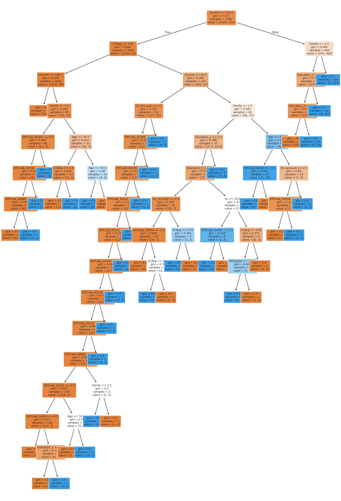

```python
# Display the Decision Tree for this training data
plt.figure(figsize=(20, 30))
out = tree.plot_tree(
    model,
    feature_names=feature_names,
    filled=True,
    fontsize=9,
    node_ids=False,
    class_names=None,
 )
 # Add arrows to the decision tree split if they are missing
for o in out:
    arrow = o.arrow_patch
    if arrow is not None:
        arrow.set_edgecolor("black")
        arrow.set_linewidth(1)
plt.show()
```